# Experiment 1.

Kenny Smith and Jennifer Culbertson

06/08/2020

# Introduction

Data analysis for Experiment 1.

# Load the data.

```r
exp1Data <- read.csv('../RawData/exp1Data.csv')

#day needs to be a factor for the stats
exp1Data$Day <- as.factor(exp1Data$Day)

#at some point we switched terminology in the paper from Agents Can/Cannot be Patients to Subjects Can/Cannot Be Objects - need to correct this throughout
exp1Data$EventType <- revalue(exp1Data$EventType,
                              c("Agents Cannot Be Patients"="Subjects Cannot Be Objects",
                                "Agents Can Be Patients"="Subjects Can Be Objects"))

#it will be useful to have Subjects Cannot Be Objects as baseline
exp1Data$EventType <- relevel(as.factor(exp1Data$EventType),
                                        ref='Subjects Cannot Be Objects')
```

# Counts of participants and participant exclusions per day

```r
#got this from https://stackoverflow.com/questions/12840294/counting-unique-distinct-values-by-group-in-a-data-frame
exp1.counts.table <- ddply(exp1Data,~Day,summarise,N=length(unique(workerId)))
exp1.counts.table
```

```
##   Day   N
## 1   1 145
## 2   2 122
## 3   3 112
## 4   4 100
```

```r
exp1.scores.by.block <- aggregate(score~workerId+Day+Block,data=exp1Data,FUN=mean)
exp1.failed.noun.comprehension <- subset(exp1.scores.by.block,Block=='NounComprehension2' & score<0.7)
exp1.failed.sentence.comprehension <- subset(exp1.scores.by.block,Block=='SentenceComprehension1' & score<0.7)
ddply(exp1.failed.sentence.comprehension,~Day,summarise,N_excluded=length(unique(workerId)))
```

```
##   Day N_excluded
## 1   1          1
```

# Counts of grammatical/ungrammatical trials

Including these so we can see how they were calculated.

```r
aggregate(grammatical~Day,FUN=mean,data=subset(exp1Data,Block=="SentenceTest1"))
```

```
##   Day grammatical
## 1   2   0.7403689
## 2   3   0.8169643
## 3   4   0.8462500
```

```r
rejection.counts <- ddply(subset(exp1Data,Block=="SentenceTest1" & grammatical==0),~wordorder,summarise,N=length(unique(workerId)))
#ordered list of rejection types, if you want to see it - quite long
rejection.counts <- rejection.counts[order(-rejection.counts$N),]
```

# Results

## Identification accuracy on comprehension trials

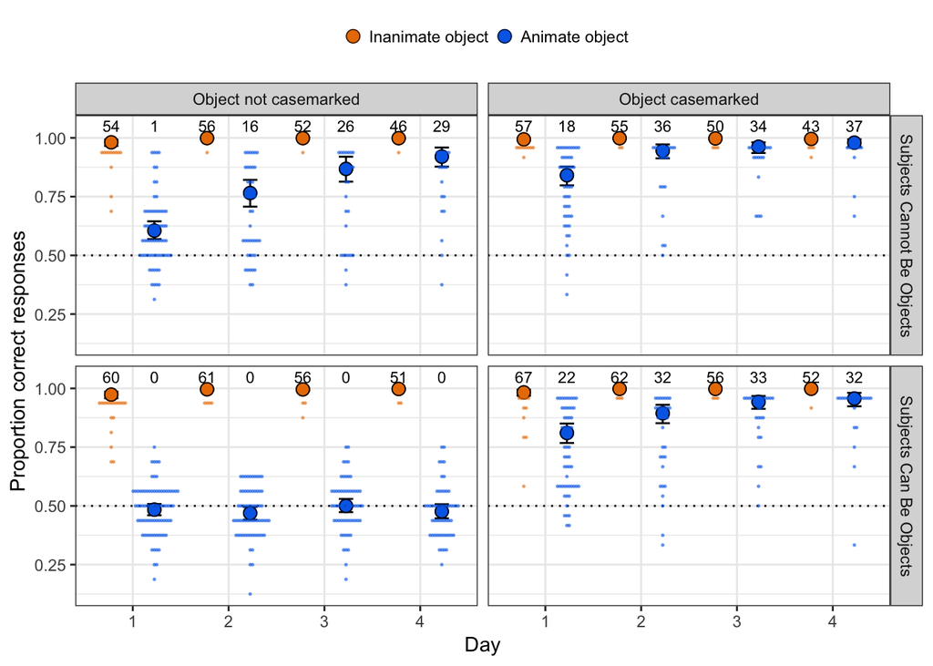

```r
#this takes amazingly long, commenting out for now
exp1.score.model.1 <- glmer(score~casemarked * Day * EventType + (1 | workerId) + (0 + casemarked*Day | workerId),data=subset(exp1Data,Block=="SentenceComprehension1" & Animacy),family=binomial,control=glmerControl(optimizer="bobyqa",optCtrl=list(maxfun=50000)))
```

```
## boundary (singular) fit: see ?isSingular
```

Model 1 is singular, reducing.

```r
exp1.score.model.2 <- glmer(score~casemarked * Day * EventType + (1 | workerId) + (0 + casemarked+Day | workerId),data=subset(exp1Data,Block=="SentenceComprehension1" & Animacy),family=binomial,control=glmerControl(optimizer="bobyqa",optCtrl=list(maxfun=50000)))
```

```
## boundary (singular) fit: see ?isSingular
```

Model 2 is singular as well, reducing further.

```r
exp1.score.model.3 <- glmer(score~casemarked * Day * EventType + (1 | workerId) + (0 + casemarked | workerId),data=subset(exp1Data,Block=="SentenceComprehension1" & Animacy),family=binomial,control=glmerControl(optimizer="bobyqa",optCtrl=list(maxfun=50000)))
```

```
## boundary (singular) fit: see ?isSingular
```

Model 3 is singular as well, reducing further.

```r
exp1.score.model.4 <- glmer(score~casemarked * Day * EventType + (1 | workerId) + (0 + Day | workerId),data=subset(exp1Data,Block=="SentenceComprehension1" & Animacy),family=binomial,control=glmerControl(optimizer="bobyqa",optCtrl=list(maxfun=50000)))
```

```
## boundary (singular) fit: see ?isSingular
```

So everything apart from the (1|WorkerID) model is singular.

```r
exp1.score.model.simpler <- glmer(score~casemarked * Day * EventType + (1 | workerId),data=subset(exp1Data,Block=="SentenceComprehension1" & Animacy),family=binomial,control=glmerControl(optimizer="bobyqa",optCtrl=list(maxfun=50000)))
```

```r
summary(exp1.score.model.simpler)
```

```
## Generalized linear mixed model fit by maximum likelihood (Laplace Approximation) ['glmerMod']
##  Family: binomial  ( logit )
## Formula: score ~ casemarked * Day * EventType + (1 | workerId)
##    Data: subset(exp1Data, Block == "SentenceComprehension1" & Animacy)
## Control: glmerControl(optimizer = "bobyqa", optCtrl = list(maxfun = 50000))
##
##      AIC      BIC   logLik deviance df.resid
##  15098.7  15232.3  -7532.3  15064.7    19103
##
## Scaled residuals:
##      Min       1Q   Median       3Q      Max
## -12.3118   0.1128   0.2456   0.4175   2.2544
##
## Random effects:
##  Groups   Name        Variance Std.Dev.
##  workerId (Intercept) 0.4434   0.6659
## Number of obs: 19120, groups:  workerId, 144
##
## Fixed effects:
##                                                      Estimate Std. Error z value Pr(>|z|)
## (Intercept)                                           0.49289    0.10651   4.627 3.70e-06 ***
## casemarkedTRUE                                        1.39774    0.09926  14.082  < 2e-16 ***
## Day2                                                  0.84559    0.10808   7.824 5.12e-15 ***
## Day3                                                  1.59715    0.12755  12.522  < 2e-16 ***
## Day4                                                  2.23751    0.15679  14.271  < 2e-16 ***
## EventTypeSubjects Can Be Objects                     -0.56544    0.14284  -3.959 7.54e-05 ***
## casemarkedTRUE:Day2                                   0.40226    0.17608   2.284   0.0223 *
## casemarkedTRUE:Day3                                   0.04042    0.20710   0.195   0.8452
## casemarkedTRUE:Day4                                   0.08500    0.27095   0.314   0.7537
## casemarkedTRUE:EventTypeSubjects Can Be Objects       0.19212    0.12980   1.480   0.1388
## Day2:EventTypeSubjects Can Be Objects                -0.91843    0.13915  -6.600 4.10e-11 ***
## Day3:EventTypeSubjects Can Be Objects                -1.51894    0.15637  -9.714  < 2e-16 ***
## Day4:EventTypeSubjects Can Be Objects                -2.26286    0.18261 -12.391  < 2e-16 ***
## casemarkedTRUE:Day2:EventTypeSubjects Can Be Objects  0.36609    0.22132   1.654   0.0981 .
## casemarkedTRUE:Day3:EventTypeSubjects Can Be Objects  1.28284    0.26006   4.933 8.10e-07 ***
## casemarkedTRUE:Day4:EventTypeSubjects Can Be Objects  1.62889    0.32339   5.037 4.73e-07 ***
## ---
## Signif. codes:  0 '***' 0.001 '**' 0.01 '*' 0.05 '.' 0.1 ' ' 1
```

```
##
## Correlation matrix not shown by default, as p = 16 > 12.
## Use print(x, correlation=TRUE)  or
##     vcov(x)        if you need it
```

Performance at the intercept is significantly above 50%, but is roughly what would be expected if participants made optimal use of word order cues to agency, 60% of sentences used SOV order, which would yield an expected log odds of success for an attentive learner of:

```r
prob2logit(0.6)
```

```
## [1] 0.4054651
```

, which is not significantly different from the success rates of our participants:

```r
my.logodds.p(0.6,exp1.score.model.simpler,"(Intercept)")
```

```
## [1] 0.411764
```

## Case marking and animacy during sentence recall

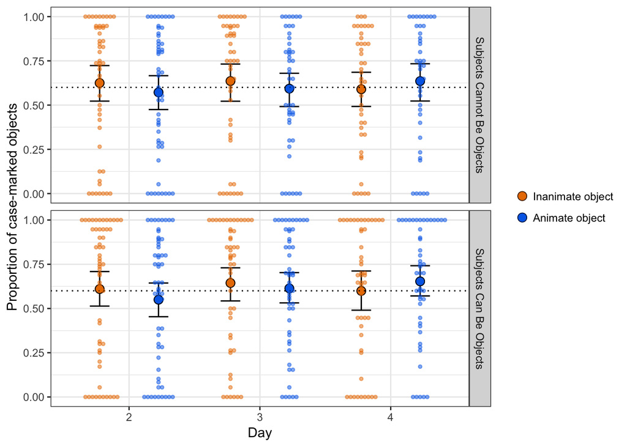

```r
exp1.casemarking.summary.by.animacy <- aggregate(casemarked~Animacy+Day+EventType+workerId,data=subset(exp1Data,Block=="SentenceTest1" & grammatical),FUN=mean)


ggplot(data=exp1.casemarking.summary.by.animacy, aes(x=Day, y=casemarked,
                                                     colour=Animacy,fill=Animacy)) +
  facet_grid(EventType~.) +
  #bars and CIs for casemarking by animacy
  stat_summary(geom='errorbar', fun.data='mean_cl_boot',fun.ymin="min", fun.ymax="max",width=0.3,position=position_dodge(0.9),colour='black') +
  stat_summary(geom='point',fun.y='mean', position=position_dodge(0.9),size=3) +
  stat_summary(geom='point',fun.y='mean', position=position_dodge(0.9),size=3,shape=1,colour='black') +


  #horizontal line showing input
  geom_hline(yintercept=0.6,linetype=3) +
  #by-participant data
  geom_dotplot(aes(x=Day, y=casemarked, shape=Animacy),binaxis = "y", stackdir = "centerwhole",stackratio=1,alpha=0.5,dotsize=2,position=position_dodge(0.9),binpositions='all',binwidth=1/100) +

  #force all points to be circles, and exclude from legend
  scale_shape_manual(values=c(21,21),guide=FALSE)+
  #then various axis/legend stuff
  xlab("Day") +
  theme_bw() +
  ylab("Proportion of case-marked objects") +
  theme(legend.title=element_blank()) +
  scale_fill_manual(values=my.colours[2:3],breaks=c("FALSE", "TRUE"),labels=c("Inanimate object", "Animate object")) +
  scale_colour_manual(values=my.colours[2:3],breaks=c("FALSE", "TRUE"),labels=c("Inanimate object", "Animate object")) +
  ggsave("../Figures/exp1-casemarking.pdf",width=9, height=9)
```

```r
#Using a coding scheme such that the estimate for animacy and condition will be the effect of a one-unit difference - i.e. unlike contr.sum you don't have to double this.
exp1Data$Animacy <- factor(exp1Data$Animacy)
contrasts(exp1Data$Animacy) <- c(-0.5,0.5)
contrasts(exp1Data$EventType) <- c(-0.5,0.5)
exp1.case.marking.model.1 <- glmer(casemarked ~ Animacy * Day * EventType + (1 + Animacy * Day | workerId),data=subset(exp1Data,Block=="SentenceTest1" & grammatical),family=binomial,control=glmerControl(optimizer="bobyqa",optCtrl=list(maxfun=50000)))
```

```r
summary(exp1.case.marking.model.1)
```

```
## Generalized linear mixed model fit by maximum likelihood (Laplace Approximation) ['glmerMod']
##  Family: binomial  ( logit )
## Formula: casemarked ~ Animacy * Day * EventType + (1 + Animacy * Day |      workerId)
##    Data: subset(exp1Data, Block == "SentenceTest1" & grammatical)
## Control: glmerControl(optimizer = "bobyqa", optCtrl = list(maxfun = 50000))
##
##      AIC      BIC   logLik deviance df.resid
##   9215.2   9455.2  -4574.6   9149.2    10625
##
## Scaled residuals:
##     Min      1Q  Median      3Q     Max
## -5.5006 -0.3101  0.1575  0.5125  5.9258
##
## Random effects:
##  Groups   Name          Variance Std.Dev. Corr
##  workerId (Intercept)   8.289    2.879
##           Animacy1      3.507    1.873    -0.11
##           Day3          2.852    1.689    -0.29  0.02
##           Day4          5.060    2.249    -0.39  0.00  0.84
##           Animacy1:Day3 2.969    1.723    -0.19 -0.44 -0.20 -0.07
##           Animacy1:Day4 2.163    1.471    -0.01 -0.52 -0.09 -0.05  0.86
## Number of obs: 10658, groups:  workerId, 114
##
## Fixed effects:
##                          Estimate Std. Error z value Pr(>|z|)
## (Intercept)               0.49959    0.28267   1.767  0.07716 .
## Animacy1                 -0.43163    0.21778  -1.982  0.04749 *
## Day3                      0.27326    0.19381   1.410  0.15856
## Day4                      0.45962    0.25117   1.830  0.06726 .
## EventType1               -0.14754    0.56330  -0.262  0.79338
## Animacy1:Day3             0.15418    0.23857   0.646  0.51811
## Animacy1:Day4             0.68940    0.22738   3.032  0.00243 **
## Animacy1:EventType1       0.01092    0.43407   0.025  0.97993
## Day3:EventType1           0.53198    0.38598   1.378  0.16812
## Day4:EventType1           0.60260    0.49930   1.207  0.22747
## Animacy1:Day3:EventType1 -0.21258    0.47623  -0.446  0.65532
## Animacy1:Day4:EventType1 -0.05840    0.44796  -0.130  0.89628
## ---
## Signif. codes:  0 '***' 0.001 '**' 0.01 '*' 0.05 '.' 0.1 ' ' 1
##
## Correlation of Fixed Effects:
##             (Intr) Anmcy1 Day3   Day4   EvntT1 An1:D3 An1:D4 A1:ET1 D3:ET1 D4:ET1 A1:D3:
## Animacy1    -0.092
## Day3        -0.332  0.036
## Day4        -0.410  0.014  0.763
## EventType1  -0.050  0.001  0.009  0.016
## Animcy1:Dy3 -0.115 -0.528 -0.175 -0.066  0.008
## Animcy1:Dy4  0.006 -0.558 -0.071 -0.040  0.000  0.693
## Anmcy1:EvT1  0.001 -0.040  0.001  0.001 -0.091  0.008  0.006
## Dy3:EvntTy1  0.009  0.001 -0.019 -0.017 -0.329 -0.007 -0.004  0.036
## Dy4:EvntTy1  0.017  0.002 -0.017 -0.027 -0.409 -0.006 -0.010  0.012  0.763
## Anm1:D3:ET1  0.008  0.009 -0.006 -0.006 -0.116 -0.004  0.002 -0.525 -0.178 -0.066
## Anm1:D4:ET1  0.000  0.009 -0.004 -0.007  0.005  0.003  0.013 -0.563 -0.074 -0.048  0.699
```

Participants at day 2 produce case marking slightly more often than not — the odds of producing a case marker are approximately 1.6 to 1, which is not significantly different from the frequency of case marking in the input (where case marking occurs on 60% of objects, i.e. log odds of:

```r
prob2logit(0.6)
```

```
## [1] 0.4054651
```

, n.s. different from the estimated log odds on Day 2,

```r
my.logodds.p(0.6,exp1.case.marking.model.1,"(Intercept)")
```

```
## [1] 0.7391473
```

If I instead run this model on the full data set but setting day 4 as the intercept, there’s absolutely no significant effect of animacy, indicating that while the relationship between animacy and case marking changes over the course of the experiment, participants’ use of case markers on day 4 does not show a significant DOM-like effect.

Code day 4 as 0 to see if case marking is significantly affected by animacy on day 4

```r
#code day 4 as 0 to see if case marking is significantly affected by animacy on day 4
exp1Data$DayR <- relevel(exp1Data$Day,ref='4')

exp1.case.marking.model.1.r <- glmer(casemarked ~ Animacy * DayR * EventType + (1 + Animacy * DayR | workerId),data=subset(exp1Data,Block=="SentenceTest1" & grammatical),family=binomial,control=glmerControl(optimizer="bobyqa",optCtrl=list(maxfun=50000)))
```

```r
summary(exp1.case.marking.model.1.r)
```

```
## Generalized linear mixed model fit by maximum likelihood (Laplace Approximation) ['glmerMod']
##  Family: binomial  ( logit )
## Formula: casemarked ~ Animacy * DayR * EventType + (1 + Animacy * DayR |      workerId)
##    Data: subset(exp1Data, Block == "SentenceTest1" & grammatical)
## Control: glmerControl(optimizer = "bobyqa", optCtrl = list(maxfun = 50000))
##
##      AIC      BIC   logLik deviance df.resid
##   9215.2   9455.2  -4574.6   9149.2    10625
##
## Scaled residuals:
##     Min      1Q  Median      3Q     Max
## -5.5006 -0.3101  0.1575  0.5125  5.9256
##
## Random effects:
##  Groups   Name           Variance Std.Dev. Corr
##  workerId (Intercept)    8.2385   2.8703
##           Animacy1       2.8089   1.6760   -0.16
##           DayR2          5.0601   2.2495   -0.39  0.04
##           DayR3          1.5577   1.2481   -0.20  0.01  0.67
##           Animacy1:DayR2 2.1632   1.4708    0.05 -0.30 -0.05  0.04
##           Animacy1:DayR3 0.7961   0.8923   -0.40  0.02  0.05 -0.22  0.00
## Number of obs: 10658, groups:  workerId, 114
##
## Fixed effects:
##                           Estimate Std. Error z value Pr(>|z|)
## (Intercept)                0.95921    0.29101   3.296  0.00098 ***
## Animacy1                   0.25777    0.20928   1.232  0.21806
## DayR2                     -0.45962    0.25129  -1.829  0.06739 .
## DayR3                     -0.18635    0.16238  -1.148  0.25113
## EventType1                 0.45507    0.57983   0.785  0.43256
## Animacy1:DayR2            -0.68941    0.22747  -3.031  0.00244 **
## Animacy1:DayR3            -0.53522    0.18284  -2.927  0.00342 **
## Animacy1:EventType1       -0.04745    0.41220  -0.115  0.90835
## DayR2:EventType1          -0.60258    0.49938  -1.207  0.22757
## DayR3:EventType1          -0.07060    0.32278  -0.219  0.82687
## Animacy1:DayR2:EventType1  0.05838    0.44855   0.130  0.89645
## Animacy1:DayR3:EventType1 -0.15420    0.35895  -0.430  0.66749
## ---
## Signif. codes:  0 '***' 0.001 '**' 0.01 '*' 0.05 '.' 0.1 ' ' 1
##
## Correlation of Fixed Effects:
##             (Intr) Anmcy1 DayR2  DayR3  EvntT1 An1:DR2 An1:DR3 A1:ET1 DR2:ET DR3:ET A1:DR2:
## Animacy1    -0.112
## DayR2       -0.464  0.028
## DayR3       -0.317 -0.003  0.636
## EventType1  -0.040 -0.006  0.009  0.006
## Anmcy1:DyR2  0.029 -0.505 -0.040  0.023  0.008
## Anmcy1:DyR3 -0.183 -0.363  0.036 -0.112  0.015  0.339
## Anmcy1:EvT1 -0.004 -0.013  0.007  0.006 -0.121 -0.020  -0.010
## DyR2:EvntT1  0.007  0.009 -0.028 -0.022 -0.461 -0.010  -0.005   0.038
## DyR3:EvntT1  0.004  0.011 -0.022 -0.030 -0.311 -0.012  -0.014   0.009  0.634
## An1:DR2:ET1  0.006 -0.023 -0.008 -0.006  0.036  0.013   0.013  -0.492 -0.048  0.014
## An1:DR3:ET1  0.011 -0.015 -0.002 -0.006 -0.180  0.014   0.005  -0.339  0.027 -0.130  0.318
```

## Identification accuracy during interaction

What does communicative accuracy look like in interaction?

```r
#since there is some data munging here, will set this up as a seperate data frame
exp1InteractionSuccessData <- droplevels(subset(exp1Data,((Block=="Interaction" & grammatical) | (Block=="InteractionMatch")) & Day==4))
exp1InteractionSuccessData$Animacy <- as.factor(exp1InteractionSuccessData$Animacy)

exp1.interaction.success.summary <- aggregate(score~Block+Animacy+EventType+casemarked+workerId,data=exp1InteractionSuccessData,FUN=mean)

exp1.interaction.success.summary$casemarked <- revalue(as.factor(exp1.interaction.success.summary$casemarked),
                                    c("FALSE"="Object not casemarked",
                                      "TRUE"="Object casemarked"))
exp1.interaction.success.summary$Block <- plyr::revalue(exp1.interaction.success.summary$Block,
                                                        c("Interaction"="Participant Directs,\nSmeeble Matches",
                                                          "InteractionMatch"="Smeeble Directs,\nParticipant Matches"))

#for the dotplot, there are too many participants at ceiling to show the dots - instead I am going
#to withhold those dots and add a numerical annotation
exp1.interaction.success.summary$IsPerfect <- ifelse(exp1.interaction.success.summary$score==1,1,0)
exp1.interaction.score.perfect.ns <- data.frame(summarize(group_by(subset(exp1.interaction.success.summary,IsPerfect==1),Block,Animacy,casemarked,EventType,.drop = FALSE),n()))
exp1.interaction.score.perfect.ns <- plyr::rename(exp1.interaction.score.perfect.ns,c("n.."="count"))
```

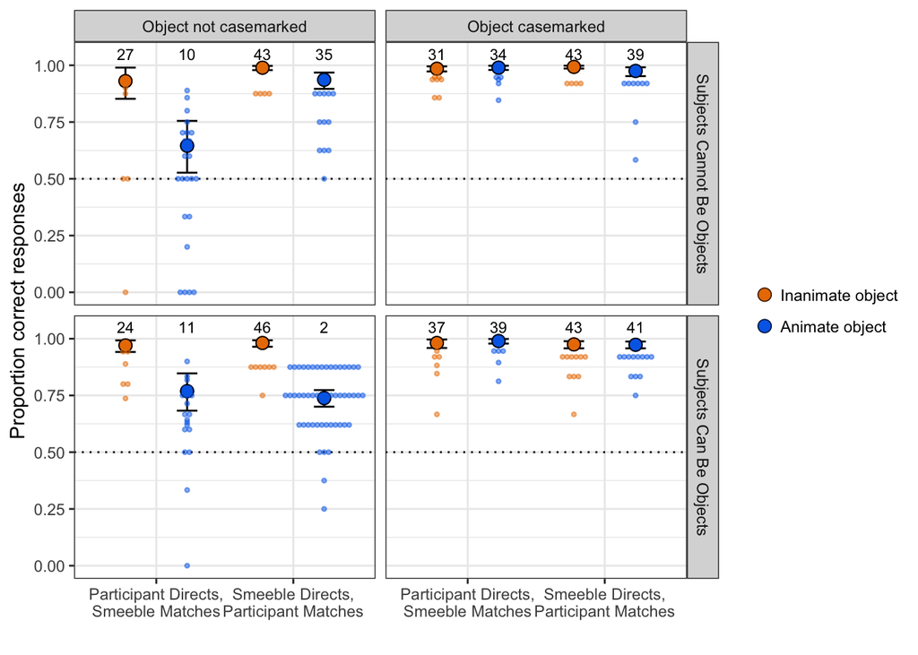

```r
ggplot(data=exp1.interaction.success.summary, aes(x=Block, y=score,
                                                  colour=Animacy,fill=Animacy)) +
  facet_grid(EventType~casemarked) +
  #points and CIs for casemarking by animacy
  stat_summary(geom='errorbar', fun.data='mean_cl_boot',fun.ymin="min",
               fun.ymax="max",width=0.3,position=position_dodge(0.9),color='black') +
  stat_summary(geom='point', fun.y='mean', position=position_dodge(0.9),size=3) +
  stat_summary(geom='point', fun.y='mean', position=position_dodge(0.9),size=3,
               shape=1,colour='black') +


  #horizontal line showing chance
  geom_hline(yintercept=0.5,linetype=3) +
  #by-participant data
  geom_dotplot(data=subset(exp1.interaction.success.summary,IsPerfect==0),aes(x=Block, y=score, shape=Animacy),binaxis = "y", stackdir = "center",alpha=0.5,dotsize=2,position=position_dodge(0.9),binpositions='all',binwidth=1/100) +

  geom_text(data=exp1.interaction.score.perfect.ns,aes(x=Block,y=1.05,label=count),position=position_dodge(0.9),size=3,colour='black') +
  #then various axis/legend stuff
  xlab("") +
  theme_bw() +
  scale_y_continuous(name="Proportion correct responses",breaks=seq(0,1,0.25)) +
  theme(legend.title=element_blank()) +
  scale_colour_manual(values=my.colours[c(2,3)],breaks=c("FALSE", "TRUE"),labels=c("Inanimate object", "Animate object")) +
  scale_fill_manual(values=my.colours[c(2,3)],breaks=c("FALSE", "TRUE"),labels=c("Inanimate object", "Animate object")) +
  ggsave("../Figures/exp1-interaction-success.pdf",width=9, height=6)
```

```r
#I am going to want to dummy-code this so Subjects Cannot Be Objects is baseline
contrasts(exp1InteractionSuccessData$EventType) <- NULL
#I am going to want to dummy-code this so participant-directs is baseline
contrasts(exp1InteractionSuccessData$Block) <- NULL


exp1.interaction.success.model.1 <- glmer(score ~ Animacy * Block * EventType + (1 + Animacy * Block | workerId),data=subset(exp1InteractionSuccessData,casemarked==FALSE),family=binomial,control=glmerControl(optimizer="bobyqa",optCtrl=list(maxfun=50000)))
```

```
## boundary (singular) fit: see ?isSingular
```

That produces singular fit, simlplifying by removing correlation.

```r
#I am going to want to dummy-code this so Subjects Cannot Be Objects is baseline
contrasts(exp1InteractionSuccessData$EventType) <- NULL
#I am going to want to dummy-code this so participant-directs is baseline
contrasts(exp1InteractionSuccessData$Block) <- NULL


exp1.interaction.success.model.1 <- glmer(score ~ Animacy * Block * EventType + (1 | workerId) + (0 + Animacy * Block | workerId),data=subset(exp1InteractionSuccessData,casemarked==FALSE),family=binomial,control=glmerControl(optimizer="bobyqa",optCtrl=list(maxfun=50000)))
```

```
## boundary (singular) fit: see ?isSingular
```

## Case marking and animacy during interaction

```r
#since there is some data munging here, will set this up as a seperate data frame
exp1RecallVsInteractionData <- subset(exp1Data,(Block=="Interaction" | Block=="SentenceTest1") & grammatical & Day==4)
#want recall to be the reference level
exp1RecallVsInteractionData$Block <- relevel(droplevels(exp1RecallVsInteractionData$Block),ref="SentenceTest1")

exp1.recall.vs.interaction.summary <- aggregate(casemarked~Animacy+Block+workerId+EventType,data=exp1RecallVsInteractionData,FUN=mean)


#prettier names for printing
exp1.recall.vs.interaction.summary$Block <- revalue(exp1.recall.vs.interaction.summary$Block,
                                         c("SentenceTest1"="Recall",
                                           "Interaction"="Interaction"))
```

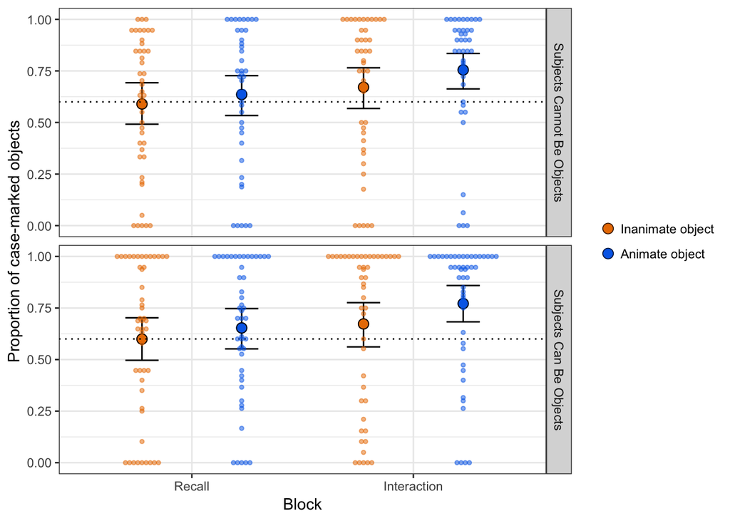

```r
ggplot(data=exp1.recall.vs.interaction.summary, aes(x=Block, y=casemarked,
                                                    colour=Animacy, fill=Animacy)) +
  facet_grid(EventType~.) +
  #points and CIs for casemarking by animacy
  stat_summary(geom='errorbar', fun.data='mean_cl_boot',fun.ymin="min", fun.ymax="max",width=0.3,position=position_dodge(0.9),color='black') +
  stat_summary(geom='point', fun.y='mean', position=position_dodge(0.9),size=3) +
  stat_summary(geom='point', fun.y='mean', position=position_dodge(0.9),size=3,
               shape=1,colour='black') +


  #horizontal line showing input
  geom_hline(yintercept=0.6,linetype=3) +
  #by-participant data
  geom_dotplot(aes(x=Block, y=casemarked, shape=Animacy),binaxis = "y", stackdir = "center",alpha=0.5,dotsize=2,position=position_dodge(0.9),binpositions='all',binwidth=1/100) +
  #then various axis/legend stuff
  xlab("Block") +
  theme_bw() +
  ylab("Proportion of case-marked objects") +
  theme(legend.title=element_blank()) +
  scale_colour_manual(values=my.colours[2:3],breaks=c("FALSE", "TRUE"),labels=c("Inanimate object", "Animate object")) +
  scale_fill_manual(values=my.colours[2:3],breaks=c("FALSE", "TRUE"),labels=c("Inanimate object", "Animate object")) +
  ggsave("../Figures/exp1-interaction-casemarking.pdf",width=9, height=6)
```

```r
exp1RecallVsInteractionData$Animacy <- factor(exp1RecallVsInteractionData$Animacy)
contrasts(exp1RecallVsInteractionData$Animacy) <- c(-0.5,0.5)
contrasts(exp1RecallVsInteractionData$EventType) <- c(-0.5,0.5)
#I am going to want to dummy-code this so recall is baseline
contrasts(exp1RecallVsInteractionData$Block) <- NULL


exp1.recall.vs.interaction.model.1 <- glmer(casemarked ~ Animacy * Block * EventType + (1 + Animacy *  Block | workerId),data=exp1RecallVsInteractionData,family=binomial,control=glmerControl(optimizer="bobyqa"))
```

```r
summary(exp1.recall.vs.interaction.model.1)
```

```
## Generalized linear mixed model fit by maximum likelihood (Laplace Approximation) ['glmerMod']
##  Family: binomial  ( logit )
## Formula: casemarked ~ Animacy * Block * EventType + (1 + Animacy * Block |      workerId)
##    Data: exp1RecallVsInteractionData
## Control: glmerControl(optimizer = "bobyqa")
##
##      AIC      BIC   logLik deviance df.resid
##   5315.0   5437.9  -2639.5   5279.0     6797
##
## Scaled residuals:
##     Min      1Q  Median      3Q     Max
## -6.6302 -0.1566  0.1358  0.4262  3.9041
##
## Random effects:
##  Groups   Name                      Variance Std.Dev. Corr
##  workerId (Intercept)               9.2411   3.0399
##           Animacy1                  2.6536   1.6290   -0.24
##           BlockInteraction          3.2306   1.7974   -0.27 -0.34
##           Animacy1:BlockInteraction 0.5261   0.7253   -0.14  0.30  0.23
## Number of obs: 6815, groups:  workerId, 92
##
## Fixed effects:
##                                       Estimate Std. Error z value Pr(>|z|)
## (Intercept)                           0.871410   0.327658   2.660  0.00783 **
## Animacy1                              0.190682   0.209671   0.909  0.36312
## BlockInteraction                      0.951524   0.220481   4.316 1.59e-05 ***
## EventType1                            0.531134   0.654518   0.811  0.41709
## Animacy1:BlockInteraction             0.432743   0.203454   2.127  0.03342 *
## Animacy1:EventType1                  -0.005076   0.418219  -0.012  0.99032
## BlockInteraction:EventType1           0.123101   0.437032   0.282  0.77819
## Animacy1:BlockInteraction:EventType1  0.224475   0.373088   0.602  0.54740
## ---
## Signif. codes:  0 '***' 0.001 '**' 0.01 '*' 0.05 '.' 0.1 ' ' 1
##
## Correlation of Fixed Effects:
##             (Intr) Anmcy1 BlckIn EvntT1 An1:BI A1:ET1 BI:ET1
## Animacy1    -0.186
## BlckIntrctn -0.302 -0.254
## EventType1  -0.053  0.003  0.004
## Anmcy1:BlcI -0.056 -0.186  0.115  0.008
## Anmcy1:EvT1  0.003 -0.014  0.024 -0.187 -0.024
## BlckInt:ET1  0.006  0.023  0.006 -0.306 -0.002 -0.256
## Anm1:BI:ET1  0.007 -0.022  0.000 -0.061  0.133 -0.179  0.108
```

## Relationship between animacy and word order

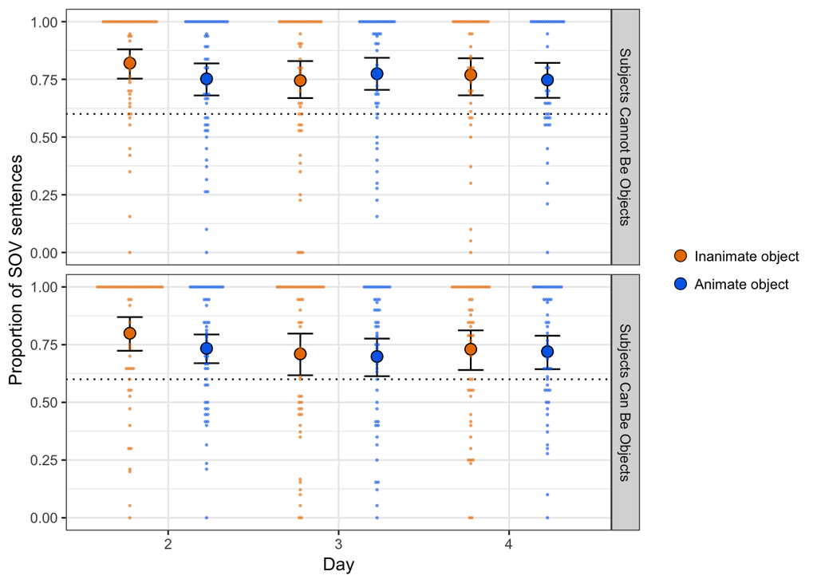

```r
exp1.sov.summary.by.animacy <- aggregate(isSOV~Animacy+Day+EventType+workerId,data=subset(exp1Data,Block=="SentenceTest1" & grammatical),FUN=mean)


ggplot(data=exp1.sov.summary.by.animacy, aes(x=Day, y=isSOV, fill=Animacy, colour=Animacy)) +
  facet_grid(EventType~.) +
  #points and CIs for word order by animacy
  stat_summary(geom='errorbar', fun.data='mean_cl_boot',fun.ymin="min", fun.ymax="max",width=0.3,position=position_dodge(0.9),color='black') +
  stat_summary(geom='point', fun.y='mean', position=position_dodge(0.9), size=3) +
  stat_summary(geom='point', fun.y='mean', position=position_dodge(0.9), size=3, shape=1, colour='black') +

  #horizontal line showing input
  geom_hline(yintercept=0.6,linetype=3) +
  #by-participant data
  geom_dotplot(aes(x=Day, y=isSOV, shape=Animacy),binaxis = "y", stackdir = "center",alpha=0.5,dotsize=1,position=position_dodge(0.9),binpositions='all',binwidth=1/100) +
  #then various axis/legend stuff
  xlab("Day") +
  theme_bw() +
  ylab("Proportion of SOV sentences") +
  theme(legend.title=element_blank()) +
  scale_colour_manual(values=my.colours[2:3],breaks=c("FALSE", "TRUE"),labels=c("Inanimate object", "Animate object")) +
  scale_fill_manual(values=my.colours[2:3],breaks=c("FALSE", "TRUE"),labels=c("Inanimate object", "Animate object")) +
  ggsave("../Figures/exp1-wordorder.pdf",width=9, height=9)
```

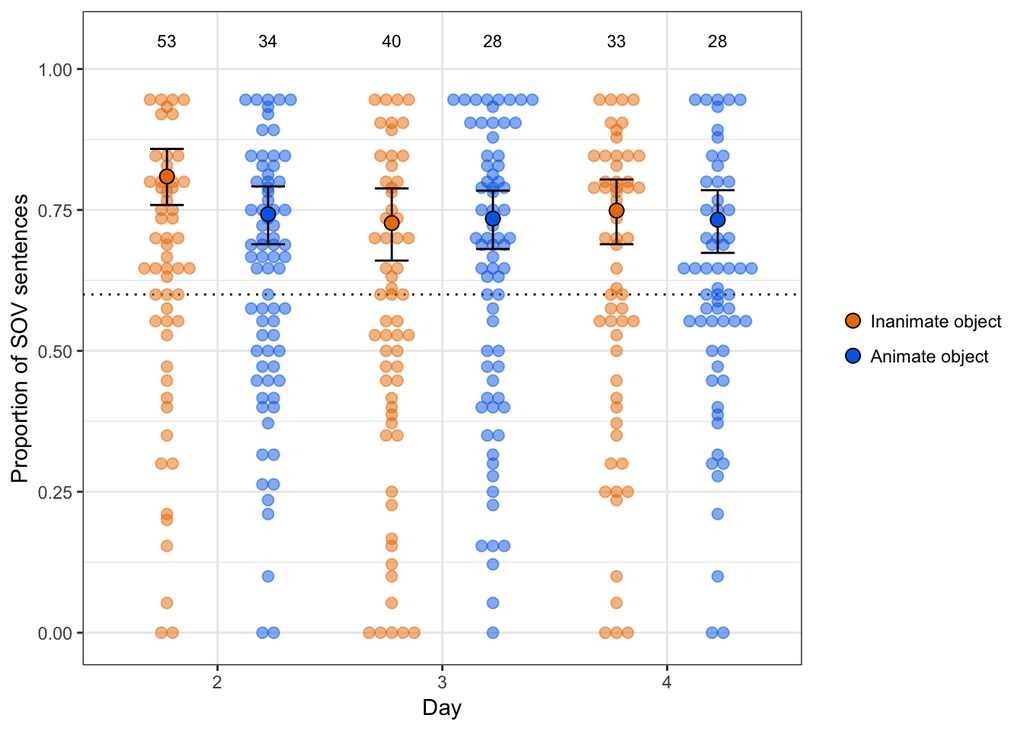

```r
exp1.sov.summary.by.animacy.collapsed <- aggregate(isSOV~Animacy+Day+workerId,data=subset(exp1Data,Block=="SentenceTest1" & grammatical),FUN=mean)


#for the collapsed dotplot, there are too many participants at ceiling to show the dots - instead I am going
#to withhold those dots and add a numerical annotation
exp1.sov.summary.by.animacy.collapsed$IsPerfect <- ifelse(exp1.sov.summary.by.animacy.collapsed$isSOV==1,1,0)
exp1.sov.summary.by.animacy.collapsed$Day <- droplevels(exp1.sov.summary.by.animacy.collapsed$Day)
exp1.allsov.ns <- data.frame(summarize(group_by(subset(exp1.sov.summary.by.animacy.collapsed,IsPerfect==1 & Day!=1),Day,Animacy,.drop = FALSE),n()))
exp1.allsov.ns <- plyr::rename(exp1.allsov.ns,c("n.."="count"))



ggplot(data=exp1.sov.summary.by.animacy.collapsed, aes(x=Day, y=isSOV, fill=Animacy,colour=Animacy)) +


  #horizontal line showing input
  geom_hline(yintercept=0.6,linetype=3) +

  #by-participant data
  geom_dotplot(data=subset(exp1.sov.summary.by.animacy.collapsed,IsPerfect!=1),aes(x=Day, y=isSOV, shape=Animacy),binaxis = "y", stackdir = "center",alpha=0.5,dotsize=2,position=position_dodge(0.9),binpositions='all',binwidth=1/100) +
  geom_text(data=exp1.allsov.ns,aes(x=Day,y=1.05,label=count),position=position_dodge(0.9),size=3,colour='black') +

  #points and CIs for word order by animacy
  stat_summary(geom='errorbar', fun.data='mean_cl_boot',fun.ymin="min", fun.ymax="max",width=0.3,position=position_dodge(0.9),color='black') +
  stat_summary(geom='point', fun.y='mean', position=position_dodge(0.9), size=3) +
  stat_summary(geom='point', fun.y='mean', position=position_dodge(0.9), size=3, shape=1, colour='black') +


  #then various axis/legend stuff
  xlab("Day") +
  theme_bw() +
  ylab("Proportion of SOV sentences") +
  theme(legend.title=element_blank()) +
  scale_colour_manual(values=my.colours[2:3],breaks=c("FALSE", "TRUE"),labels=c("Inanimate object", "Animate object")) +
  scale_fill_manual(values=my.colours[2:3],breaks=c("FALSE", "TRUE"),labels=c("Inanimate object", "Animate object")) +
  ggsave("../Figures/exp1-wordorder-collapsed.pdf",width=9, height=4.5)
```

This produces a singular fit.

```r
exp1.sovorder.model.1 <- glmer(isSOV ~ Animacy * EventType * Day + (1 + Animacy * Day | workerId),data=subset(exp1Data,Block=="SentenceTest1" & grammatical),family=binomial,control=glmerControl(optimizer="bobyqa",optCtrl=list(maxfun=50000)))
```

```
## boundary (singular) fit: see ?isSingular
```

Simplifying, removing correlation between intercept and random slopes.

```r
exp1.sovorder.model.2 <- glmer(isSOV ~ Animacy * EventType * Day + (1 | workerId) + (0 + Animacy * Day | workerId),data=subset(exp1Data,Block=="SentenceTest1" & grammatical),family=binomial,control=glmerControl(optimizer="bobyqa",optCtrl=list(maxfun=50000)))
```

```
## boundary (singular) fit: see ?isSingular
```

Simplifying further, remove interaction in random slopes, converges

```r
exp1.sovorder.model.3 <- glmer(isSOV ~ Animacy * EventType * Day + (1 + Animacy + Day | workerId),data=subset(exp1Data,Block=="SentenceTest1" & grammatical),family=binomial,control=glmerControl(optimizer="bobyqa",optCtrl=list(maxfun=50000)))
```

```r
summary(exp1.sovorder.model.3)
```

```
## Generalized linear mixed model fit by maximum likelihood (Laplace Approximation) ['glmerMod']
##  Family: binomial  ( logit )
## Formula: isSOV ~ Animacy * EventType * Day + (1 + Animacy + Day | workerId)
##    Data: subset(exp1Data, Block == "SentenceTest1" & grammatical)
## Control: glmerControl(optimizer = "bobyqa", optCtrl = list(maxfun = 50000))
##
##      AIC      BIC   logLik deviance df.resid
##   8765.3   8925.4  -4360.7   8721.3    10636
##
## Scaled residuals:
##     Min      1Q  Median      3Q     Max
## -6.5145 -0.1836  0.1447  0.5092  4.1453
##
## Random effects:
##  Groups   Name        Variance Std.Dev. Corr
##  workerId (Intercept) 6.108    2.471
##           Animacy1    1.275    1.129    -0.55
##           Day3        3.045    1.745    -0.34  0.00
##           Day4        4.068    2.017    -0.34 -0.02  0.76
## Number of obs: 10658, groups:  workerId, 114
##
## Fixed effects:
##                          Estimate Std. Error z value Pr(>|z|)
## (Intercept)               2.39344    0.25873   9.251  < 2e-16 ***
## Animacy1                 -0.93014    0.17318  -5.371 7.84e-08 ***
## EventType1               -0.38967    0.49902  -0.781 0.434887
## Day3                     -0.35486    0.22103  -1.605 0.108394
## Day4                     -0.28127    0.25301  -1.112 0.266261
## Animacy1:EventType1      -0.06890    0.31226  -0.221 0.825363
## Animacy1:Day3             0.54830    0.14261   3.845 0.000121 ***
## Animacy1:Day4             0.32566    0.14777   2.204 0.027540 *
## EventType1:Day3          -0.31301    0.41063  -0.762 0.445894
## EventType1:Day4           0.16813    0.47371   0.355 0.722647
## Animacy1:EventType1:Day3 -0.22679    0.28247  -0.803 0.422032
## Animacy1:EventType1:Day4  0.08827    0.29177   0.303 0.762256
## ---
## Signif. codes:  0 '***' 0.001 '**' 0.01 '*' 0.05 '.' 0.1 ' ' 1
##
## Correlation of Fixed Effects:
##             (Intr) Anmcy1 EvntT1 Day3   Day4   An1:ET1 An1:D3 An1:D4 ET1:D3 ET1:D4 A1:ET1:D3
## Animacy1    -0.398
## EventType1  -0.067  0.021
## Day3        -0.429  0.062  0.032
## Day4        -0.412  0.029  0.032  0.667
## Anmcy1:EvT1  0.022 -0.092 -0.407  0.002  0.005
## Animcy1:Dy3  0.043 -0.437  0.005 -0.076 -0.051  0.020
## Animcy1:Dy4  0.043 -0.429  0.003 -0.056 -0.082  0.029   0.520
## EvntTyp1:D3  0.038 -0.006 -0.394 -0.094 -0.042  0.052  -0.020 -0.008
## EvntTyp1:D4  0.035 -0.004 -0.387 -0.046 -0.075  0.033  -0.009 -0.012  0.691
## Anm1:ET1:D3  0.007  0.009  0.034 -0.020 -0.008 -0.465  -0.042 -0.015 -0.063 -0.047
## Anm1:ET1:D4  0.002  0.026  0.036 -0.006 -0.007 -0.461  -0.011 -0.071 -0.053 -0.068  0.521
```

The log-odds of producing SOV order are significantly higher than the frequency of SOV in the input:

```r
my.logodds.p(0.6,exp1.sovorder.model.2,"(Intercept)")
```

```
## [1] 2.667558e-14
```

Relevelled model, to test for effect of animacy on word order at day=4? It’s still there, which is surprising looking at the graphs.

```r
#NB simplified random effects to match model 2 above
exp1.sovorder.model.r <- glmer(isSOV ~ Animacy * EventType * DayR + (1 + Animacy + DayR | workerId),data=subset(exp1Data,Block=="SentenceTest1" & grammatical),family=binomial,control=glmerControl(optimizer="bobyqa",optCtrl=list(maxfun=50000)))
```

```r
summary(exp1.sovorder.model.r)
```

```
## Generalized linear mixed model fit by maximum likelihood (Laplace Approximation) ['glmerMod']
##  Family: binomial  ( logit )
## Formula: isSOV ~ Animacy * EventType * DayR + (1 + Animacy + DayR | workerId)
##    Data: subset(exp1Data, Block == "SentenceTest1" & grammatical)
## Control: glmerControl(optimizer = "bobyqa", optCtrl = list(maxfun = 50000))
##
##      AIC      BIC   logLik deviance df.resid
##   8765.3   8925.4  -4360.7   8721.3    10636
##
## Scaled residuals:
##     Min      1Q  Median      3Q     Max
## -6.5172 -0.1836  0.1447  0.5092  4.1456
##
## Random effects:
##  Groups   Name        Variance Std.Dev. Corr
##  workerId (Intercept) 6.768    2.601
##           Animacy1    1.276    1.130    -0.54
##           DayR2       4.070    2.017    -0.45  0.02
##           DayR3       1.791    1.338    -0.33  0.03  0.52
## Number of obs: 10658, groups:  workerId, 114
##
## Fixed effects:
##                           Estimate Std. Error z value Pr(>|z|)
## (Intercept)                2.11289    0.27757   7.612  2.7e-14 ***
## Animacy1                  -0.60522    0.17284  -3.502 0.000462 ***
## EventType1                -0.22174    0.53790  -0.412 0.680170
## DayR2                      0.28179    0.25304   1.114 0.265429
## DayR3                     -0.07376    0.19562  -0.377 0.706144
## Animacy1:EventType1        0.01960    0.31406   0.062 0.950249
## Animacy1:DayR2            -0.32568    0.14775  -2.204 0.027503 *
## Animacy1:DayR3             0.22264    0.14235   1.564 0.117820
## EventType1:DayR2          -0.16838    0.47352  -0.356 0.722151
## EventType1:DayR3          -0.48116    0.35180  -1.368 0.171399
## Animacy1:EventType1:DayR2 -0.08824    0.29183  -0.302 0.762360
## Animacy1:EventType1:DayR3 -0.31501    0.28095  -1.121 0.262185
## ---
## Signif. codes:  0 '***' 0.001 '**' 0.01 '*' 0.05 '.' 0.1 ' ' 1
##
## Correlation of Fixed Effects:
##             (Intr) Anmcy1 EvntT1 DayR2  DayR3  An1:ET1 A1:DR2 A1:DR3 ET1:DR2 ET1:DR3 A1:ET1:DR2
## Animacy1    -0.375
## EventType1  -0.062  0.008
## DayR2       -0.527  0.041  0.036
## DayR3       -0.448  0.069  0.035  0.540
## Anmcy1:EvT1  0.020 -0.100 -0.371  0.002 -0.001
## Anmcy1:DyR2  0.035 -0.424  0.008 -0.082 -0.043  0.037
## Anmcy1:DyR3  0.030 -0.435  0.004 -0.035 -0.065  0.049   0.517
## EvntTy1:DR2  0.035  0.015 -0.518 -0.074 -0.045  0.029  -0.012 -0.003
## EvntTy1:DR3  0.044  0.005 -0.415 -0.051 -0.120  0.043  -0.007 -0.019  0.538
## An1:ET1:DR2  0.005  0.034  0.025 -0.007 -0.003 -0.469  -0.071 -0.062 -0.069  -0.030
## An1:ET1:DR3  0.004  0.032  0.018  0.001 -0.016 -0.466  -0.059 -0.091 -0.025  -0.042   0.514
```

## Word order and case correlation

Recall that in the input SOV is more likely to be case marked than OSV. Very little suggestion that they learnt this, which could just indicate poor learning *or* that means they are over-producing case-markers with OSV and under-producing with SOV, which is consistent with the effect of animacy on word order.

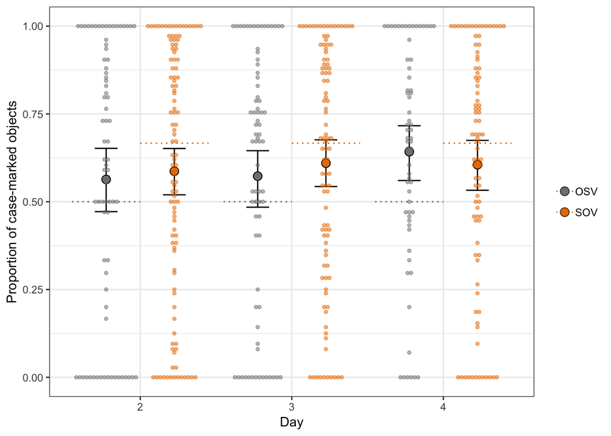

```r
exp1.case.summary.by.order.collapsed <- aggregate(casemarked~Day+WordOrder+workerId,data=subset(exp1Data,Block=="SentenceTest1" & grammatical),FUN=mean)

#input levels
exp1.inputs <- data.frame(Day=rep(c(1,2,3),2),
                          WordOrder=rep(c('OSV','SOV'),each=3),
                          casemarked=rep(c(1/2,2/3),each=3))

ggplot(data=exp1.case.summary.by.order.collapsed, aes(x=Day, y=casemarked, fill=WordOrder, colour=WordOrder)) +
  #points and CIs for marking by word order
  stat_summary(geom='errorbar', fun.data='mean_cl_boot',fun.ymin="min", fun.ymax="max",width=0.3,position=position_dodge(0.9),color='black') +
  stat_summary(geom='point', fun.y='mean', position=position_dodge(0.9), size=3) +
  stat_summary(geom='point', fun.y='mean', position=position_dodge(0.9), size=3, shape=1, colour='black') +

  #horizontal lines showing input
  geom_errorbar(data=exp1.inputs, aes(x=Day,ymax=casemarked, ymin=casemarked),position=position_dodge(0.9),linetype=3) +

  #by-participant data
  geom_dotplot(aes(x=Day, y=casemarked, shape=WordOrder),binaxis = "y", stackdir = "center",alpha=0.5,dotsize=1,position=position_dodge(0.9),binpositions='all',binwidth=1/100) +

  #then various axis/legend stuff
  xlab("Day") +
  theme_bw() +
  ylab("Proportion of case-marked objects") +
  theme(legend.title=element_blank()) +
  scale_fill_manual(values=my.colours) +
  scale_colour_manual(values=my.colours) +
  ggsave("../Figures/exp1-case-by-order-collapsed.pdf",width=9, height=4.5)
```

```r
exp1.caseorder.model.1 <- glmer(casemarked ~ WordOrder * Day + (1 + WordOrder * Day | workerId),data=subset(exp1Data,Block=="SentenceTest1" & grammatical),family=binomial,control=glmerControl(optimizer="bobyqa",optCtrl=list(maxfun=50000)))
```

```r
summary(exp1.caseorder.model.1)
```

```
## Generalized linear mixed model fit by maximum likelihood (Laplace Approximation) ['glmerMod']
##  Family: binomial  ( logit )
## Formula: casemarked ~ WordOrder * Day + (1 + WordOrder * Day | workerId)
##    Data: subset(exp1Data, Block == "SentenceTest1" & grammatical)
## Control: glmerControl(optimizer = "bobyqa", optCtrl = list(maxfun = 50000))
##
##      AIC      BIC   logLik deviance df.resid
##   9463.4   9659.8  -4704.7   9409.4    10631
##
## Scaled residuals:
##     Min      1Q  Median      3Q     Max
## -6.6391 -0.3456  0.1602  0.5168  4.6504
##
## Random effects:
##  Groups   Name              Variance Std.Dev. Corr
##  workerId (Intercept)       7.643    2.765
##           WordOrderSOV      6.907    2.628    -0.42
##           Day3              3.667    1.915    -0.60  0.67
##           Day4              4.340    2.083    -0.72  0.52  0.89
##           WordOrderSOV:Day3 8.043    2.836     0.48 -0.73 -0.70 -0.53
##           WordOrderSOV:Day4 7.785    2.790     0.50 -0.74 -0.62 -0.50  0.94
## Number of obs: 10658, groups:  workerId, 114
##
## Fixed effects:
##                   Estimate Std. Error z value Pr(>|z|)
## (Intercept)        0.34659    0.33262   1.042    0.297
## WordOrderSOV       0.19090    0.33307   0.573    0.567
## Day3               0.12750    0.29269   0.436    0.663
## Day4               0.43338    0.32036   1.353    0.176
## WordOrderSOV:Day3  0.05518    0.37252   0.148    0.882
## WordOrderSOV:Day4 -0.10272    0.38551  -0.266    0.790
##
## Correlation of Fixed Effects:
##             (Intr) WrOSOV Day3   Day4   WOSOV:D3
## WordOrdrSOV -0.622
## Day3        -0.672  0.686
## Day4        -0.731  0.615  0.782
## WrdOrSOV:D3  0.557 -0.739 -0.776 -0.561
## WrdOrSOV:D4  0.574 -0.743 -0.616 -0.685  0.813
```

## Effects of animacy controlling for word order?

Given that animacy influences both word order and case marking, and case marking is conditioned on word order, we might want to add word order as an additional predictor into the model - although we should worry about the effects of colinearity. We don’t want word order interacting with Condition - I can’t think why we would anyway - so the model specification is a bit hairy…

```r
exp1.case.marking.model.2 <- glmer(casemarked ~ Animacy * Day * (WordOrder + EventType)
                                   + (1 | workerId)
                                   + (0 + Animacy * Day * WordOrder | workerId),
                                   data=subset(exp1Data,Block=="SentenceTest1" & grammatical),family=binomial,control=glmerControl(optimizer="bobyqa",optCtrl=list(maxfun=100000)))
```

```
## boundary (singular) fit: see ?isSingular
```

That produces singular fit - simplifying by pulling out the 3-way interaction. Singular fit.

```r
exp1.case.marking.model.3 <- glmer(casemarked ~ Animacy * Day * (WordOrder + EventType)
                                   + (1 | workerId)
                                   + (0 + Animacy * WordOrder * Day - Day:Animacy:WordOrder   | workerId),
                                   data=subset(exp1Data,Block=="SentenceTest1" & grammatical),family=binomial,control=glmerControl(optimizer="bobyqa",optCtrl=list(maxfun=100000)))
```

```
## boundary (singular) fit: see ?isSingular
```

```r
exp1.case.marking.model.4 <- glmer(casemarked ~ Animacy * Day * (WordOrder + EventType)

                                   + (1 | workerId)
                                   + (0 + Animacy * WordOrder * Day
                                      - Day:Animacy:WordOrder
                                      - Day:Animacy | workerId),
                                   data=subset(exp1Data,Block=="SentenceTest1" & grammatical),family=binomial,control=glmerControl(optimizer="bobyqa",optCtrl=list(maxfun=50000)))

exp1.case.marking.model.5 <- glmer(casemarked ~ Animacy * Day * (WordOrder + EventType)
                                   + (1 | workerId)
                                   + (0 + Animacy * WordOrder * Day
                                      - Day:Animacy:WordOrder
                                      - Day:WordOrder | workerId),
                                   data=subset(exp1Data,Block=="SentenceTest1" & grammatical),family=binomial,control=glmerControl(optimizer="bobyqa",optCtrl=list(maxfun=50000)))
```

```
## boundary (singular) fit: see ?isSingular
```

```r
summary(exp1.case.marking.model.4)
```

```
## Generalized linear mixed model fit by maximum likelihood (Laplace Approximation) ['glmerMod']
##  Family: binomial  ( logit )
## Formula: casemarked ~ Animacy * Day * (WordOrder + EventType) + (1 | workerId) +      (0 + Animacy * WordOrder * Day - Day:Animacy:WordOrder -          Day:Animacy | workerId)
##    Data: subset(exp1Data, Block == "SentenceTest1" & grammatical)
## Control: glmerControl(optimizer = "bobyqa", optCtrl = list(maxfun = 50000))
##
##      AIC      BIC   logLik deviance df.resid
##   8881.5   9281.6  -4385.8   8771.5    10603
##
## Scaled residuals:
##     Min      1Q  Median      3Q     Max
## -6.5378 -0.2761  0.1301  0.4509  4.8404
##
## Random effects:
##  Groups     Name                  Variance Std.Dev. Corr
##  workerId   (Intercept)           2.176    1.475
##  workerId.1 AnimacyFALSE          7.088    2.662
##             AnimacyTRUE           9.503    3.083     0.77
##             WordOrderSOV          7.925    2.815    -0.38 -0.51
##             Day3                  4.182    2.045    -0.72 -0.65  0.67
##             Day4                  5.457    2.336    -0.82 -0.81  0.53  0.89
##             Animacy1:WordOrderSOV 3.318    1.822    -0.15 -0.50  0.36  0.17  0.22
##             WordOrderSOV:Day3     9.778    3.127     0.63  0.47 -0.75 -0.71 -0.52 -0.01
##             WordOrderSOV:Day4     9.168    3.028     0.63  0.54 -0.76 -0.65 -0.50 -0.09  0.94
## Number of obs: 10658, groups:  workerId, 114
##
## Fixed effects:
##                             Estimate Std. Error z value Pr(>|z|)
## (Intercept)                 0.517762   0.368589   1.405  0.16011
## Animacy1                   -0.933086   0.329028  -2.836  0.00457 **
## Day3                       -0.030106   0.318504  -0.095  0.92469
## Day4                        0.389801   0.352684   1.105  0.26905
## WordOrderSOV                0.071877   0.359215   0.200  0.84141
## EventType1                 -0.018628   0.595585  -0.031  0.97505
## Animacy1:Day3              -0.174127   0.315222  -0.552  0.58068
## Animacy1:Day4               0.711601   0.322166   2.209  0.02719 *
## Animacy1:WordOrderSOV       0.686454   0.346543   1.981  0.04761 *
## Animacy1:EventType1        -0.203410   0.406233  -0.501  0.61657
## Day3:WordOrderSOV           0.255624   0.408493   0.626  0.53146
## Day4:WordOrderSOV          -0.006077   0.415971  -0.015  0.98834
## Day3:EventType1             0.302187   0.388401   0.778  0.43655
## Day4:EventType1             0.211245   0.518209   0.408  0.68354
## Animacy1:Day3:WordOrderSOV  0.498057   0.360106   1.383  0.16664
## Animacy1:Day4:WordOrderSOV -0.122863   0.368718  -0.333  0.73897
## Animacy1:Day3:EventType1   -0.037550   0.306343  -0.123  0.90244
## Animacy1:Day4:EventType1   -0.048313   0.316056  -0.153  0.87851
## ---
## Signif. codes:  0 '***' 0.001 '**' 0.01 '*' 0.05 '.' 0.1 ' ' 1
```

```
##
## Correlation matrix not shown by default, as p = 18 > 12.
## Use print(x, correlation=TRUE)  or
##     vcov(x)        if you need it
```

```r
car::vif(exp1.case.marking.model.4)
```

```
##                            GVIF Df GVIF^(1/(2*Df))
## Animacy                3.656947  1        1.912315
## Day                    5.159699  2        1.507149
## WordOrder              3.405264  1        1.845336
## EventType              1.532096  1        1.237779
## Animacy:Day           19.744573  2        2.107958
## Animacy:WordOrder      3.722162  1        1.929290
## Animacy:EventType      1.236495  1        1.111978
## Day:WordOrder          7.702330  2        1.665925
## Day:EventType          1.551331  2        1.116031
## Animacy:Day:WordOrder 20.031282  2        2.115569
## Animacy:Day:EventType  1.249405  2        1.057245
```

Want to relevel that model and check for effect of animacy at day=4.

```r
exp1.case.marking.model.4r <- glmer(casemarked ~ Animacy * DayR * (WordOrder + EventType)
                                   + (1 | workerId)
                                   + (0 + Animacy * WordOrder * DayR
                                      - DayR:Animacy:WordOrder
                                      - DayR:Animacy | workerId),
                                   data=subset(exp1Data,Block=="SentenceTest1" & grammatical),family=binomial,control=glmerControl(optimizer="bobyqa",optCtrl=list(maxfun=50000)))
```

```r
summary(exp1.case.marking.model.4r)
```

```
## Generalized linear mixed model fit by maximum likelihood (Laplace Approximation) ['glmerMod']
##  Family: binomial  ( logit )
## Formula: casemarked ~ Animacy * DayR * (WordOrder + EventType) + (1 |      workerId) + (0 + Animacy * WordOrder * DayR - DayR:Animacy:WordOrder -      DayR:Animacy | workerId)
##    Data: subset(exp1Data, Block == "SentenceTest1" & grammatical)
## Control: glmerControl(optimizer = "bobyqa", optCtrl = list(maxfun = 50000))
##
##      AIC      BIC   logLik deviance df.resid
##   8881.5   9281.6  -4385.8   8771.5    10603
##
## Scaled residuals:
##     Min      1Q  Median      3Q     Max
## -6.5375 -0.2761  0.1301  0.4509  4.8403
##
## Random effects:
##  Groups     Name                  Variance Std.Dev. Corr
##  workerId   (Intercept)           1.784    1.336
##  workerId.1 AnimacyFALSE          2.686    1.639
##             AnimacyTRUE           3.655    1.912     0.38
##             WordOrderSOV          4.054    2.014     0.66  0.15
##             DayR2                 5.450    2.335    -0.09  0.09  0.01
##             DayR3                 1.146    1.071    -0.01  0.27 -0.06  0.48
##             Animacy1:WordOrderSOV 3.317    1.821     0.07 -0.54  0.37 -0.22 -0.16
##             WordOrderSOV:DayR2    9.159    3.026    -0.30 -0.26 -0.43 -0.50  0.14  0.09
##             WordOrderSOV:DayR3    1.169    1.081    -0.05 -0.37 -0.16  0.11 -0.21  0.21  0.08
## Number of obs: 10658, groups:  workerId, 114
##
## Fixed effects:
##                             Estimate Std. Error z value Pr(>|z|)
## (Intercept)                  0.90735    0.25124   3.611 0.000305 ***
## Animacy1                    -0.22143    0.30993  -0.714 0.474941
## DayR2                       -0.38945    0.35211  -1.106 0.268699
## DayR3                       -0.41970    0.21925  -1.914 0.055581 .
## WordOrderSOV                 0.06575    0.26968   0.244 0.807373
## EventType1                   0.19317    0.50860   0.380 0.704080
## Animacy1:DayR2              -0.71164    0.32159  -2.213 0.026906 *
## Animacy1:DayR3              -0.88580    0.28013  -3.162 0.001566 **
## Animacy1:WordOrderSOV        0.56351    0.33304   1.692 0.090636 .
## Animacy1:EventType1         -0.25165    0.41079  -0.613 0.540131
## DayR2:WordOrderSOV           0.00596    0.41536   0.014 0.988552
## DayR3:WordOrderSOV           0.26173    0.24782   1.056 0.290900
## DayR2:EventType1            -0.21073    0.51776  -0.407 0.684010
## DayR3:EventType1             0.09129    0.33152   0.275 0.783023
## Animacy1:DayR2:WordOrderSOV  0.12291    0.36792   0.334 0.738337
## Animacy1:DayR3:WordOrderSOV  0.62098    0.33051   1.879 0.060265 .
## Animacy1:DayR2:EventType1    0.04830    0.31578   0.153 0.878433
## Animacy1:DayR3:EventType1    0.01073    0.29612   0.036 0.971080
## ---
## Signif. codes:  0 '***' 0.001 '**' 0.01 '*' 0.05 '.' 0.1 ' ' 1
```

```
##
## Correlation matrix not shown by default, as p = 18 > 12.
## Use print(x, correlation=TRUE)  or
##     vcov(x)        if you need it
```